# 电商用户行为分析

```python
from IPython.display import HTML
HTML('''<script>
code_show=true;
function code_toggle() {
  if (code_show){
    $(\'div.input\').hide();
  } else {
    $(\'div.input\').show();
  }
  code_show = !code_show
}
$( document ).ready(code_toggle);
</script>
  <form action="javascript:code_toggle()">
    <input type="submit" value="点击此处隐藏/显示代码.">
 </form>''')
```

```python
import missingno as msno
import pandas as pd
import numpy as np
import matplotlib as mpl
import seaborn as sns
import matplotlib.pyplot as plt
import pyecharts
from datetime import datetime
```

### 数据介绍

数据来源：天池：https : //tianchi.aliyun.com/competition/entrance/231522/introduction

该数据是关于用户在商品全集上的移动端行为和商品的具体信息信息，共有六个字段，具体含义如下：

| 字段名称: | 字段含义: |
| --- | --- |
| user_id | 用户标识 |
| item_id | 产品标识 |
| behavior_type | 用户对商品的行为类型,包括浏览、收藏、加购物车、购买，对应取值分别是1、2、3、4。 |
| user_geohash | 用户位置的空间标识，可以为空，由经纬度通过保密的算法生成 |
| item_category | 商品分类标识 |
| time | 行为时间 |

```python
user = pd.read_csv(r'D:\HSJ\电商用户行为可视化分析\tianchi_fresh_comp_train_user.csv')
user.head()
```

|  | user_id | item_id | behavior_type | user_geohash | item_category | time |
| --- | --- | --- | --- | --- | --- | --- |
| 0 | 10001082 | 285259775 | 1 | 97lk14c | 4076 | 2014-12-08 18 |
| 1 | 10001082 | 4368907 | 1 | NaN | 5503 | 2014-12-12 12 |
| 2 | 10001082 | 53616768 | 4 | NaN | 9762 | 2014-12-02 15 |
| 3 | 10001082 | 9947871 | 1 | NaN | 2825 | 2014-11-28 20 |
| 4 | 10001082 | 150720867 | 1 | 95qoghe | 3200 | 2014-12-15 08 |

```python
user.shape
```

```
(15463110, 6)
```

```python
user.info()
```

```
<class 'pandas.core.frame.DataFrame'>
RangeIndex: 15463110 entries, 0 to 15463109
Data columns (total 6 columns):
user_id          int64
item_id          int64
behavior_type    int64
user_geohash     object
item_category    int64
time             object
dtypes: int64(4), object(2)
memory usage: 707.8+ MB
```

```python
user.describe()
```

|  | user_id | item_id | behavior_type | item_category |
| --- | --- | --- | --- | --- |
| count | 1.546311e+07 | 1.546311e+07 | 1.546311e+07 | 1.546311e+07 |
| mean | 7.015207e+07 | 2.023169e+08 | 1.153780e+00 | 6.827181e+03 |
| std | 4.572019e+07 | 1.167524e+08 | 5.440445e-01 | 3.810410e+03 |
| min | 4.920000e+02 | 3.700000e+01 | 1.000000e+00 | 2.000000e+00 |
| 25% | 3.021406e+07 | 1.014015e+08 | 1.000000e+00 | 3.687000e+03 |
| 50% | 5.638708e+07 | 2.022669e+08 | 1.000000e+00 | 6.054000e+03 |
| 75% | 1.166482e+08 | 3.035247e+08 | 1.000000e+00 | 1.025800e+04 |
| max | 1.424430e+08 | 4.045625e+08 | 4.000000e+00 | 1.408000e+04 |

#### 计算缺失值

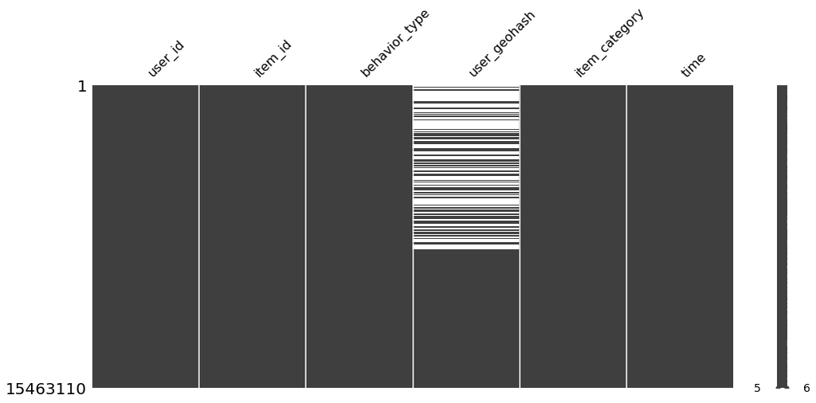

```python
msno.matrix(user.sample(15463110),   #从数据中提取500个样本
            figsize=(16, 7),
            width_ratios=(15, 1))
```

```python
user.isnull().sum()
```

```
user_id                0
item_id                0
behavior_type          0
user_geohash     8207386
item_category          0
time                   0
dtype: int64
```

从上述分析中可以看出整个数据中只有 user_geohash 存在缺失值，而 user_geohash 列表示用户位置的空间标识，在分析时用不到，所以不做处理。

### 清洗数据

```python
# 删除重复值

user.drop_duplicates(keep='last',inplace=True)
```

```python
# 将 time 列数据转换成 datetime 格式

user['time']=pd.to_datetime(user['time'])
```

```python
# 从 time 列中提取具体的月、日、时添加到用户数据集中

user['dates'] = user['time'].dt.date
user['month'] = user['dates'].values.astype('datetime64[M]')
user['hours'] = user['time'].dt.hour
user.head()
```

|  | user_id | item_id | behavior_type | user_geohash | item_category | time | dates | month | hours |
| --- | --- | --- | --- | --- | --- | --- | --- | --- | --- |
| 0 | 10001082 | 285259775 | 1 | 97lk14c | 4076 | 2014-12-08 18:00:00 | 2014-12-08 | 2014-12-01 | 18 |
| 1 | 10001082 | 4368907 | 1 | NaN | 5503 | 2014-12-12 12:00:00 | 2014-12-12 | 2014-12-01 | 12 |
| 2 | 10001082 | 53616768 | 4 | NaN | 9762 | 2014-12-02 15:00:00 | 2014-12-02 | 2014-12-01 | 15 |
| 3 | 10001082 | 9947871 | 1 | NaN | 2825 | 2014-11-28 20:00:00 | 2014-11-28 | 2014-11-01 | 20 |
| 4 | 10001082 | 150720867 | 1 | 95qoghe | 3200 | 2014-12-15 08:00:00 | 2014-12-15 | 2014-12-01 | 8 |

```python
# 转换数据类型为字符型

user['behavior_type']=user['behavior_type'].apply(str)
user['user_id']=user['user_id'].apply(str)
user['item_id']=user['item_id'].apply(str)
```

```python
user.info()
```

```
<class 'pandas.core.frame.DataFrame'>
Int64Index: 15463110 entries, 0 to 15463109
Data columns (total 9 columns):
user_id          object
item_id          object
behavior_type    object
user_geohash     object
item_category    int64
time             datetime64[ns]
dates            object
month            datetime64[ns]
hours            int64
dtypes: datetime64[ns](2), int64(2), object(5)
memory usage: 1.2+ GB
```

### 提出问题

1、用户在双十二购物活动期间和平时购买商品时有什么差别?

2、用户浏览商品后的转化率有多少？

### 用户消费分析

#### 计算每天的 PV（浏览量）和 UV（访客量）

```python
pv_everyday=user[user['behavior_type'] == "1"].groupby("dates")["behavior_type"].count()
```

```python
uv_everyday=user[user['behavior_type'] == "1"].drop_duplicates(["user_id","dates"]).groupby("dates")["user_id"].count()
```

#### PV 和 UV 可视化分析

```python
import pyecharts.options as opts
from pyecharts.charts import Line
from pyecharts.charts import Grid

# 做出每天的pv与uv趋势图
attr=list(pv_everyday.index)
pv=(
    Line(init_opts=opts.InitOpts(width="1000px",height="500px"))
    .add_xaxis(xaxis_data=attr)
    .add_yaxis(
        "pv",
        np.around(pv_everyday.values/10000,decimals=2),
        label_opts=opts.LabelOpts(is_show=False)
    )
    .add_yaxis(
        series_name="uv",
        yaxis_index=1,
        y_axis=np.around(uv_everyday.values/10000,decimals=2),
        label_opts=opts.LabelOpts(is_show=False),
    )
    .extend_axis(
        yaxis=opts.AxisOpts(
            name="uv",
            type_="value",
            min_=0,
            max_=1.6,
            interval=0.4,
            axislabel_opts=opts.LabelOpts(formatter="{value} 万人"),
        )
    )
    .set_global_opts(
        tooltip_opts=opts.TooltipOpts(
            is_show=True,trigger="axis",axis_pointer_type="cross"
        ),
        xaxis_opts=opts.AxisOpts(
            type_="category",
            axispointer_opts=opts.AxisPointerOpts(is_show=True,type_="shadow"),
        ),
        yaxis_opts=opts.AxisOpts(
            name="pv",
            type_="value",
            min_=0,
            max_=100,
            interval=20,
            axislabel_opts=opts.LabelOpts(formatter="{value} 万次"),
            axistick_opts=opts.AxisTickOpts(is_show=True),
            splitline_opts=opts.SplitLineOpts(is_show=True),
        ),
        title_opts=opts.TitleOpts(title="PV与UV分布图"),
    )
)

pv.render_notebook()
```

### 用户购物行为分析

```python
shopping_cart= user[user.behavior_type == '3'].groupby('dates')['behavior_type'].count()
collect=user[user.behavior_type=='2'].groupby('dates')['behavior_type'].count()
buy=user[user.behavior_type=='4'].groupby('dates')['behavior_type'].count()

attr_a=list(shopping_cart.index)
v_1=shopping_cart.values.tolist()
v_2=collect.values.tolist()
v_3=buy.values.tolist()

b=(
    Line()
    .add_xaxis(xaxis_data=attr_a)
    .add_yaxis(
        "加购人数",
        v_1,
        label_opts=opts.LabelOpts(is_show=False)
    )
    .add_yaxis(
        "收藏人数",
        v_2,
        label_opts=opts.LabelOpts(is_show=False)
    )
    .add_yaxis(
        "购买人数",
        v_3,
        label_opts=opts.LabelOpts(is_show=False)
    )
    .set_global_opts(title_opts=opts.TitleOpts(title="不同时期用户行为数据"))
)
b.render_notebook()
```

### 把数据拆分为活动数据和日常数据做不同时段的分析

```python
# 把 dates 列转换为 datetime 类型

user['dates']=pd.to_datetime(user['dates'])
```

```python
# 划分数据为节日数据和日常数据

double_12 = user[user["dates"].isin(["2014/12/10","2014/12/11","2014/12/12","2014/12/13"])]
daily = user[~user["dates"].isin(["2014/12/10","2014/12/11","2014/12/12","2014/12/13"])]
```

### 双12期间不同购物时间段用户行为分析

```python
from pyecharts.charts import Bar
# 活动数据
cart_h= double_12[double_12.behavior_type == '3'].groupby('hours')['behavior_type'].count()
collect_h=double_12[double_12.behavior_type=='2'].groupby('hours')['behavior_type'].count()
buy_h=double_12[double_12.behavior_type=='4'].groupby('hours')['behavior_type'].count()
uv_h=double_12[double_12.behavior_type== '1'].groupby('hours')['user_id'].count()

attr_h=list(cart_h.index)
h1=np.around(cart_h.values/3,decimals=0).tolist()
h2=np.around(collect_h.values/3,decimals=0).tolist()
h3=np.around(buy_h.values/3,decimals=0).tolist()
h4=np.around(uv_h.values/3,decimals=0).tolist()


h=(
    Line(init_opts=opts.InitOpts(width="1000px",height="500px"))
    .add_xaxis(xaxis_data=attr_h)
    .add_yaxis(
        "加购人数",
        h1,
        label_opts=opts.LabelOpts(is_show=False)
    )
    .add_yaxis(
        "收藏人数",
        h2,
        label_opts=opts.LabelOpts(is_show=False)
    )
    .add_yaxis(
        "购买人数",
        h3,
        label_opts=opts.LabelOpts(is_show=False)
    )
    .set_global_opts(
        xaxis_opts=opts.AxisOpts(axislabel_opts=opts.LabelOpts(rotate=15)),
        title_opts=opts.TitleOpts(title="日均各时段活动用户行为",pos_top="48%"),
        legend_opts=opts.LegendOpts(pos_top="48%"),
    )
)
bar=(
    Bar()
    .add_xaxis(xaxis_data=attr_h)
    .add_yaxis(
    "浏览人数",
        h4,
        label_opts=opts.LabelOpts(is_show=False)
    )
    .set_global_opts(
        title_opts=opts.TitleOpts(title="活动pv对比数据"),
    )
)

ggrid = (
    Grid()
    .add(bar, grid_opts=opts.GridOpts(pos_bottom="60%"))
    .add(h, grid_opts=opts.GridOpts(pos_top="60%"))
)
ggrid.render_notebook()
```

### 日常期间不同时间段用户行为分析

```python
# 日常数据
cart_d= daily[daily.behavior_type == '3'].groupby('hours')['behavior_type'].count()
collect_d=daily[daily.behavior_type=='2'].groupby('hours')['behavior_type'].count()
buy_d=daily[daily.behavior_type=='4'].groupby('hours')['behavior_type'].count()
uv_d=daily[daily.behavior_type== '1'].groupby('hours')['user_id'].count()

attr_d=list(cart_d.index)
d1=np.around(cart_d.values/28,decimals=0).tolist()
d2=np.around(collect_d.values/28,decimals=0).tolist()
d3=np.around(buy_d.values/28,decimals=0).tolist()
d4=np.around(uv_d.values/3,decimals=0).tolist()

d=(
    Line(init_opts=opts.InitOpts(width="1000px",height="500px"))
    .add_xaxis(xaxis_data=attr_d)
    .add_yaxis(
        "加购人数",
        d1,
        label_opts=opts.LabelOpts(is_show=False)
    )
    .add_yaxis(
        "收藏人数",
        d2,
        label_opts=opts.LabelOpts(is_show=False)
    )
    .add_yaxis(
        "购买人数",
        d3,
        label_opts=opts.LabelOpts(is_show=False)
    )
    .set_global_opts(
        xaxis_opts=opts.AxisOpts(axislabel_opts=opts.LabelOpts(rotate=15)),
        title_opts=opts.TitleOpts(title="日均各时段活动用户行为",pos_top="48%"),
        legend_opts=opts.LegendOpts(pos_top="48%"),
    )
)
y=(
    Bar()
    .add_xaxis(xaxis_data=attr_d)
    .add_yaxis(
    "浏览人数",
        d4,
        label_opts=opts.LabelOpts(is_show=False)
    )
    .set_global_opts(
        title_opts=opts.TitleOpts(title="日常pv对比数据"),
    )
)

ggrid = (
    Grid()
    .add(y, grid_opts=opts.GridOpts(pos_bottom="60%"))
    .add(d, grid_opts=opts.GridOpts(pos_top="60%"))
)
ggrid.render_notebook()
```

```python
# 活动时购买率 = 购买人数 / 活跃人数
hour_buy_user_num = double_12[double_12.behavior_type == '4'].drop_duplicates(['user_id','dates', 'hours']).groupby('hours')['user_id'].count()
hour_active_user_num = double_12.drop_duplicates(['user_id','dates', 'hours']).groupby('hours')['user_id'].count()
hour_buy_rate = hour_buy_user_num / hour_active_user_num
attr_o = list(hour_buy_user_num.index)
vo_2 =np.around(hour_buy_rate.values,decimals=2)
# 日常时购买率
hour_buy_daily_num = daily[daily.behavior_type == '4'].drop_duplicates(['user_id','dates', 'hours']).groupby('hours')['user_id'].count()
hour_active_daily_num = daily.drop_duplicates(['user_id','dates', 'hours']).groupby('hours')['user_id'].count()
daily_buy_rate = hour_buy_daily_num / hour_active_daily_num
vi_2 =np.around(daily_buy_rate.values,decimals=2)


buy_rate=(
    Line()
    .add_xaxis(xaxis_data=attr_o)
    .add_yaxis(
        "日常购买率",
        vi_2,
    )
    .add_yaxis(
        "活动购买率",
        vo_2,
    )
    .set_global_opts(title_opts=opts.TitleOpts(title="不同时段购买率"))
)

buy_rate.render_notebook()
```

### 漏斗分析

#### 活动期间漏斗分析

```python
from pyecharts.charts import Funnel

# 活动转化
a_pv=double_12[double_12.behavior_type=="1"]["user_id"].count()
a_cart=double_12[double_12.behavior_type=="3"]["user_id"].count()
a_collect=double_12[double_12.behavior_type=="2"]["user_id"].count()
a_buy=double_12[double_12.behavior_type=="4"]["user_id"].count()

a_attr=["点击","加入购物车","收藏","购买"]
values=[np.around((a_pv/a_pv*100),2),
        np.around((a_cart/a_pv*100),2),
        np.around((a_collect/a_pv*100),2),
        np.around((a_buy/a_pv*100),2),
       ]

data = [[a_attr[i], values[i]] for i in range(len(a_attr))]

Loudou_double_12=(
    Funnel()
    .add(
        series_name="用户行为",
        data_pair=data,
        gap=2,
        tooltip_opts=opts.TooltipOpts(trigger="item", formatter="{a} <br/>{b} : {c}%",is_show=True),
        label_opts=opts.LabelOpts(is_show=True, position="ourside"),
        itemstyle_opts=opts.ItemStyleOpts(border_color="#fff", border_width=1),
    )
    .set_global_opts(title_opts=opts.TitleOpts(title="用户转化漏斗", subtitle="活动"))
)

Loudou_double_12.render_notebook()
```

#### 日常期间漏斗分析

```python
# 日常转化
l_pv=daily[daily.behavior_type=="1"]["user_id"].count()
l_cart=daily[daily.behavior_type=="3"]["user_id"].count()
l_collect=daily[daily.behavior_type=="2"]["user_id"].count()
l_buy=daily[daily.behavior_type=="4"]["user_id"].count()

l_attr=["点击","加入购物车","收藏","购买"]
valuel=[np.around((l_pv/l_pv*100),2),
        np.around((l_cart/l_pv*100),2),
        np.around((l_collect/l_pv*100),2),
        np.around((l_buy/l_pv*100),2),
       ]

datal = [[l_attr[i], valuel[i]] for i in range(len(l_attr))]

Loudou_daily=(
    Funnel()
    .add(
        series_name="用户行为",
        data_pair=datal,
        gap=2,
        tooltip_opts=opts.TooltipOpts(trigger="item", formatter="{a} <br/>{b} : {c}%",is_show=True),
        label_opts=opts.LabelOpts(is_show=True, position="ourside"),
        itemstyle_opts=opts.ItemStyleOpts(border_color="#fff", border_width=1),
    )
    .set_global_opts(title_opts=opts.TitleOpts(title="用户转化漏斗", subtitle="日常"))
)
Loudou_daily.render_notebook()
```